# Examen año 2022

```r
# Contribución de cada uno de los predictores (GAMLSS)
drop1(mod_GAMLSS, parameter = 'sigma', parallel = 'multicore', ncpus = 4)
```

|  | Df | AIC | LRT | Pr(Chi) |
| --- | --- | --- | --- | --- |
|  | NA | 2396.501 | NA | NA |
| pb(tamanio) | 2.2502978 | 2397.980 | 5.97978314 | 0.06332472 |
| caso | 1.0317603 | 2395.107 | 0.67020872 | 0.42481864 |
| impuestos | 0.9596300 | 2395.522 | 0.94087817 | 0.31857881 |
| estrena | 0.9950012 | 2394.479 | -0.03221844 | 1.00000000 |

```r
drop1(mod_GAMLSS, parameter = 'mu', parallel = 'multicore', ncpus = 4)
```

|  | Df | AIC | LRT | Pr(Chi) |
| --- | --- | --- | --- | --- |
|  | NA | 2396.501 | NA | NA |
| pb(tamanio) | 0.9577906 | 2405.498 | 10.913030 | 8.801554e-04 |
| caso | 1.3351882 | 2400.835 | 7.005014 | 1.362635e-02 |
| impuestos | 1.0730173 | 2413.055 | 18.700377 | 1.783383e-05 |
| estrena | 1.2138140 | 2398.815 | 4.741408 | 4.006224e-02 |

```r
mod_GAMLSS2 <- gamlss(formula = precio ~ pb(tamanio)+caso+impuestos+estrena, sigma.formula = ~ pb(tamanio), family = GA, data = preciocasas, trace = FALSE )
summary(mod_GAMLSS2)
```

```
## Family:  c("GA", "Gamma")
##
## Call:  gamlss(formula = precio ~ pb(tamanio) + caso + impuestos +
##     estrena, sigma.formula = ~pb(tamanio), family = GA,
##     data = preciocasas, trace = FALSE)
##
## Fitting method: RS()
##
## ------------------------------------------------------------------
## Mu link function:  log
## Mu Coefficients:
##               Estimate Std. Error t value Pr(>|t|)
## (Intercept)  1.108e+01  9.499e-02 116.631  < 2e-16 ***
## pb(tamanio)  2.773e-04  6.536e-05   4.243 5.34e-05 ***
## caso        -1.993e-03  8.531e-04  -2.336   0.0217 *
## impuestos    1.993e-04  3.439e-05   5.795 9.90e-08 ***
## estrena      2.133e-01  8.171e-02   2.611   0.0106 *
## ---
## Signif. codes:  0 '***' 0.001 '**' 0.01 '*' 0.05 '.' 0.1 ' ' 1
##
## ------------------------------------------------------------------
## Sigma link function:  log
## Sigma Coefficients:
##               Estimate Std. Error t value Pr(>|t|)
## (Intercept) -1.0556914  0.1864360  -5.662 1.75e-07 ***
## pb(tamanio) -0.0001876  0.0001064  -1.764   0.0812 .
## ---
## Signif. codes:  0 '***' 0.001 '**' 0.01 '*' 0.05 '.' 0.1 ' ' 1
##
## ------------------------------------------------------------------
## NOTE: Additive smoothing terms exist in the formulas:
##  i) Std. Error for smoothers are for the linear effect only.
## ii) Std. Error for the linear terms maybe are not accurate.
## ------------------------------------------------------------------
## No. of observations in the fit:  100
## Degrees of Freedom for the fit:  9.785057
##       Residual Deg. of Freedom:  90.21494
##                       at cycle:  8
##
## Global Deviance:     2372.483
##             AIC:     2392.053
##             SBC:     2417.545
```

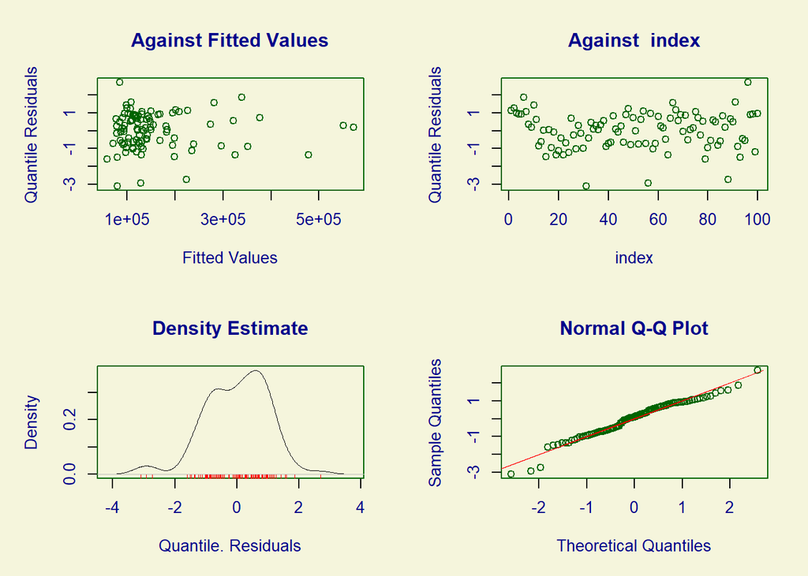

```
##        Summary of the Quantile Residuals
##                            mean   =  -0.006433068
##                        variance   =  1.006545
##                coef. of skewness  =  -0.4723284
##                coef. of kurtosis  =  3.599069
## Filliben correlation coefficient  =  0.9846261
```

```r
plot(mod_GAMLSS2)
```

```r
# Contribución de cada uno de los predictores (GAMLSS)
drop1(mod_GAMLSS2, parameter = 'sigma', parallel = 'multicore', ncpus = 4)
```

|  | Df | AIC | LRT | Pr(Chi) |
| --- | --- | --- | --- | --- |
|  | NA | 2392.053 | NA | NA |
| pb(tamanio) | 2.296995 | 2400.294 | 12.83475 | 0.002353027 |

```r
drop1(mod_GAMLSS2, parameter = 'mu', parallel = 'multicore', ncpus = 4)
```

|  | Df | AIC | LRT | Pr(Chi) |
| --- | --- | --- | --- | --- |
|  | NA | 2392.053 | NA | NA |
| pb(tamanio) | 1.156161 | 2405.238 | 15.496998 | 1.124414e-04 |
| caso | 1.232762 | 2395.384 | 5.796248 | 2.282964e-02 |
| impuestos | 2.268178 | 2418.293 | 30.776201 | 3.216445e-07 |
| estrena | 1.212915 | 2395.901 | 6.273780 | 1.705524e-02 |

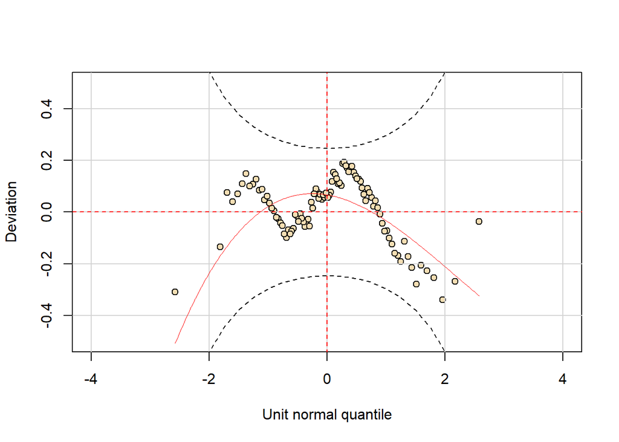

```r
# Worm plot de los residuos modelo 1
wp(mod_GAMLSS, ylim.all = 0.5)
```

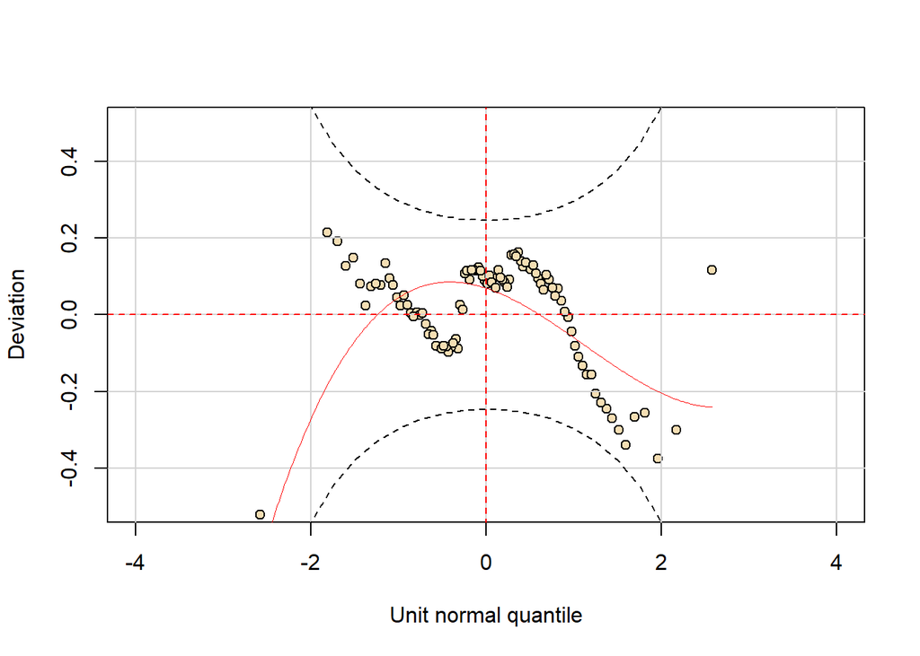

```r
# Worm plot de los residuos modelo 2
wp(mod_GAMLSS2, ylim.all = 0.5)
```

La inspección visual del wormplot de los dos modelos GAMLSS indica que estos modelos tienen los residuos dentro del rango de variación aceptable.

```r
#Comparamos los modelos ajustados:
GAIC(mod_OLS,mod_GAMLSS, mod_GAMLSS2)
```

|  | df | AIC |
| --- | --- | --- |
| mod_GAMLSS2 | 9.785057 | 2392.053 |
| mod_GAMLSS | 12.778036 | 2396.501 |
| mod_OLS | 7.097952 | 2434.416 |

De acuerdo con el criterio GAIC, el modelo GAMLSS2 es el que mejor explica la relación con el precio utilizando los mismos predictores.

En tal sentido, si sería adecuado utilizar modelos GAMLSS debido a que con estos se puede analizar conjuntos de datos que tengan comportamientos no lineales y exista presencia de heterocedasticidad.

## 8. Resuma sus conclusiones.

En general se puede concluir que del conjunto de datos preciocasas, la variable precio se puede predecir en función de la variable tamanio, esta variable tiene un comportamiento no lineal y la implementación de modelos GAMLSS permite una mejor interpretación del modelo.

# Ejercicio 2

Se desea saber si la dosis de ácido ascórbico y el tipo de bebida en la cual se lo administró a ciertos animales de laboratorio logró mayor desarrollo de los dientes en los mismo. Se utilizaron 60 replicaciones del experimento y se tienen grupos balanceados. La variable respuesta de interés es la longitud de los dientes frontales(len). Los resultados están en el archivo odonto.csv Se pide analizar, analítica y gráficamente, si:

```r
odonto<-read.csv("C:/Users/Josvaldes/Documents/Maestria/Austral/1ano/regresionAvanzada/TPRegresion/TPRegresion/examen/prueba/odonto.csv")
odonto
```

| X | len | supp | dose |
| --- | --- | --- | --- |
| 1 | 4.2 | VC | 0.5 |
| 2 | 11.5 | VC | 0.5 |
| 3 | 7.3 | VC | 0.5 |
| 4 | 5.8 | VC | 0.5 |
| 5 | 6.4 | VC | 0.5 |
| 6 | 10.0 | VC | 0.5 |
| 7 | 11.2 | VC | 0.5 |
| 8 | 11.2 | VC | 0.5 |
| 9 | 5.2 | VC | 0.5 |
| 10 | 7.0 | VC | 0.5 |

[output cut: 50 more lines]

## 1. Existen diferencias estadísticamente significativas respecto de las dosis administradas?

Se Compara los resultados según los niveles de ambas categorías.

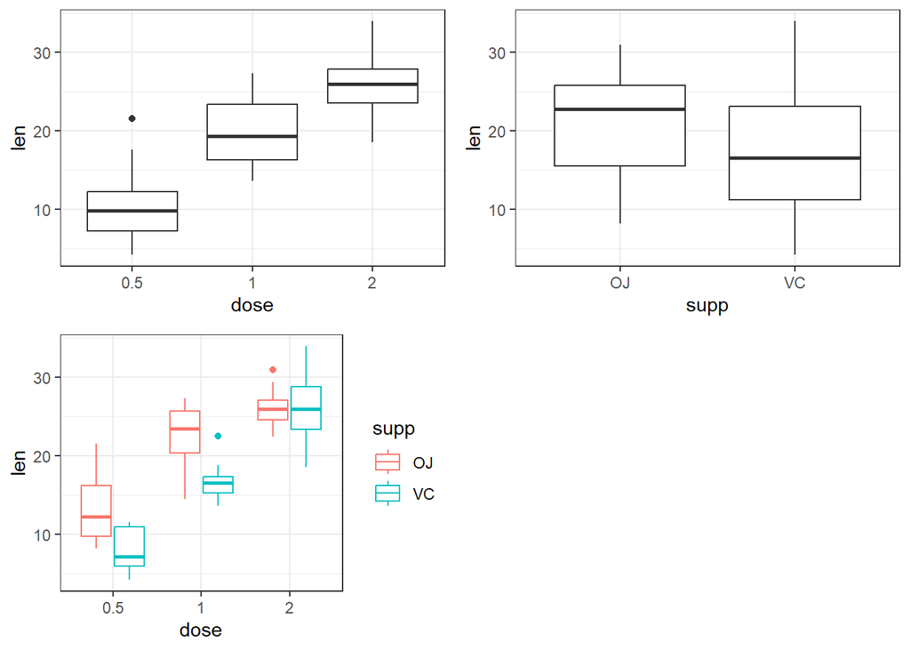

```r
library(ggplot2)
library(gridExtra)

# Se convierte la variables dose en factor
odonto$dose<-factor(odonto$dose)
odonto$supp<-factor(odonto$supp)

p1 <- ggplot(data = odonto, mapping = aes(x = dose, y = len)) + geom_boxplot() +
  theme_bw()
p2 <- ggplot(data = odonto, mapping = aes(x = supp, y = len)) + geom_boxplot() +
  theme_bw()
p3 <- ggplot(data = odonto, mapping = aes(x = dose, y = len, colour = supp)) +
  geom_boxplot() + theme_bw()
grid.arrange(p1, p2,p3, ncol = 2)
```

Parece existir interacción de las variables y diferencia de medias entre las categorías de la variable dose.

Análisis de interacciones

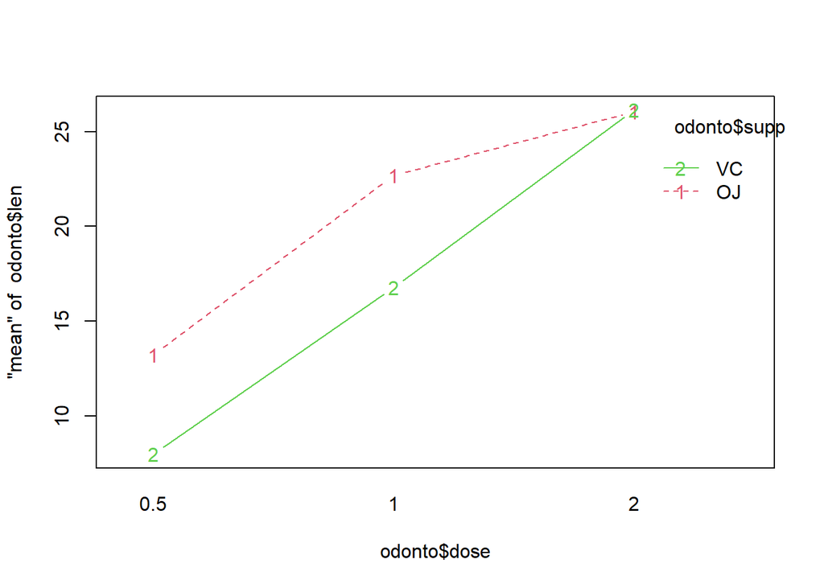

```r
interaction.plot(trace.factor = odonto$supp, x.factor = odonto$dose, response = odonto$len, fun = "mean", legend = TRUE, col = 2:3, type = "b")
```

Se observa que parece que existe interacción entre las variables dose y supp.

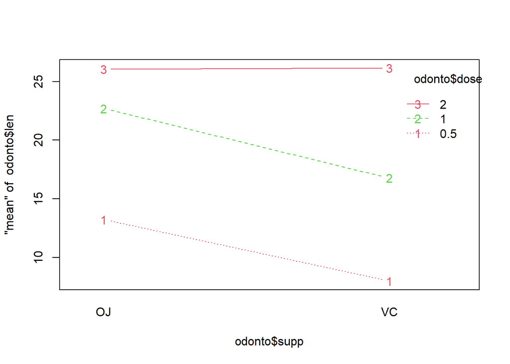

```r
interaction.plot(trace.factor = odonto$dose, x.factor = odonto$supp, response = odonto$len, fun = "mean", legend = TRUE, col = 2:3, type = "b")
```

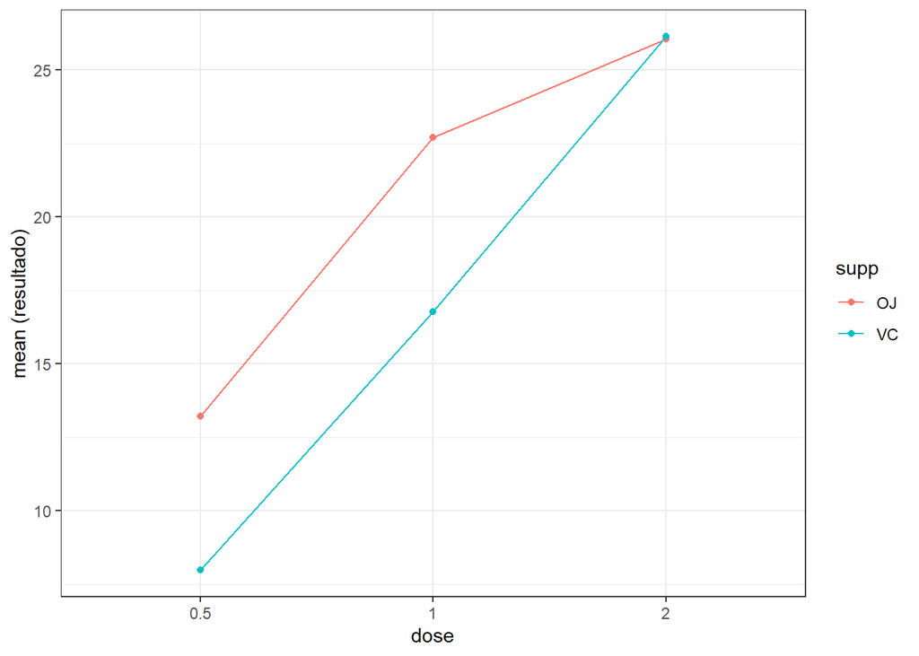

```r
ggplot(data = odonto, aes(x = dose, y = len, colour = supp, group = supp)) +
  stat_summary(fun = mean, geom = "point") + stat_summary(fun.y = mean, geom = "line") +
  labs(y = "mean (resultado)") + theme_bw()
```

Se repite la primera grafica de interacción con otro comando y se obtiene una gráfica parecida, se concluye que existe una interacción entre las variables categóricas dose y supp.

```r
anova_2vias <- aov(formula = len ~ dose*supp, data = odonto)
summary(anova_2vias)
```

```
##             Df Sum Sq Mean Sq F value   Pr(>F)
## dose         2 2426.4  1213.2  92.000  < 2e-16 ***
## supp         1  205.4   205.4  15.572 0.000231 ***
## dose:supp    2  108.3    54.2   4.107 0.021860 *
## Residuals   54  712.1    13.2
## ---
## Signif. codes:  0 '***' 0.001 '**' 0.01 '*' 0.05 '.' 0.1 ' ' 1
```

En base a los resultados:

El factor dose muestra un efecto significativo en la variable respuesta (len) debido a que el valor de p es extremadamente pequeño (< 2e-16). Esto indica que la dosis tiene un impacto estadísticamente significativo en len.

El factor supp también tiene un efecto significativo en len con un valor de p de 0.000231. Esto sugiere que el tipo de suplemento tiene un impacto significativo en la variable respuesta.

Además, la interacción entre dose y supp también es significativa con un valor de p de 0.021860. Esto indica que el efecto de la dosis sobre la variable respuesta depende del tipo de suplemento utilizado.

En general, estos resultados sugieren que tanto la dosis como el tipo de suplemento tienen un impacto significativo en la variable respuesta len, y que la interacción entre ambos factores también es relevante.

```r
library(lsr)
etaSquared(anova_2vias)
```

```
##               eta.sq eta.sq.part
## dose      0.70286419   0.7731092
## supp      0.05948365   0.2238254
## dose:supp 0.03137672   0.1320279
```

Para el factor dose, el coeficiente eta cuadrado (eta.sq) es 0.70286419, lo que indica que el 70.29% de la variabilidad total de la variable respuesta (len) se puede explicar por la variabilidad en el factor dose. Esto sugiere que dose tiene un efecto muy grande y explica una cantidad significativa de la variabilidad observada en la variable respuesta.

El coeficiente eta cuadrado parcial (eta.sq.part) para el factor dose es 0.7731092. Este valor indica la proporción de la variabilidad única explicada por dose, es decir, el efecto exclusivo de dose en la variable respuesta después de considerar otros factores en el modelo. En este caso, el 77.31% de la variabilidad única en len se puede atribuir al factor dose.

Para el factor supp, el coeficiente eta cuadrado (eta.sq) es 0.05948365, lo que indica que el 5.95% de la variabilidad total en len se puede explicar por la variabilidad en el factor supp. Esto sugiere que supp tiene un efecto más pequeño en comparación con dose en la explicación de la variabilidad en la variable respuesta.

El coeficiente eta cuadrado parcial (eta.sq.part) para el factor supp es 0.2238254. Esto indica que el 22.38% de la variabilidad única en len se puede atribuir al factor supp después de tener en cuenta otros factores en el modelo.

Para la interacción entre dose y supp (dose:supp), el coeficiente eta cuadrado (eta.sq) es 0.03137672, lo que indica que el 3.14% de la variabilidad total en len se puede explicar por la variabilidad en la interacción. Este valor sugiere que la interacción entre dose y supp también contribuye de manera significativa a la variabilidad en la variable respuesta.

Finalmente el coeficiente eta cuadrado parcial (eta.sq.part) de la interacción entre dose y supp es 0.1320279. Esto indica que el 13.20% de la variabilidad única en len se puede atribuir a la interacción entre dose y supp después de considerar otros factores en el modelo.

En resumen, los coeficientes eta cuadrado indican la proporción de variabilidad explicada por cada factor y su interacción en la variable respuesta, mientras que los coeficientes eta cuadrado parcial reflejan la proporción de variabilidad única explicada por cada factor después de considerar otros factores en el modelo. En este caso, dose tiene el mayor efecto en len, seguido por supp y la interacción entre ambos factores.

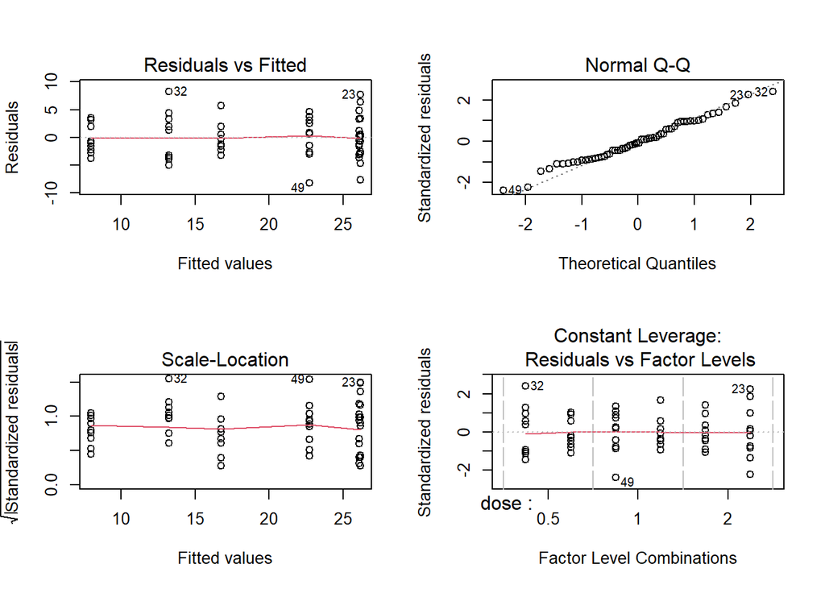

```r
par(mfrow = c(2,2))
plot(anova_2vias)
```

El resumen de los gráficos del modelo muestra al parecer el cumplimiento de los supuestos. Estos son analizados en el sub numeral 4.

Con relación a la pregunta incial, sí existen diferencias estadísticamente significativas respecto de las dosis administradas. Esto se puede deducir de la salida del análisis de varianza de dos vías (ANOVA de dos vías):

El factor dose muestra un efecto significativo en la variable respuesta (len) debido a que el valor de p es extremadamente pequeño (< 2e-16). Esto indica que la dosis tiene un impacto estadísticamente significativo en len. El valor de p extremadamente pequeño (< 2e-16) indica que la probabilidad de obtener una diferencia tan grande o mayor entre las medias de las dosis por pura casualidad es extremadamente baja. Por lo tanto, podemos concluir que hay diferencias estadísticamente significativas en la variable respuesta (len) entre las diferentes dosis administradas.

En resumen, el análisis de varianza indica que existe una diferencia estadísticamente significativa en la variable respuesta (len) en función de las dosis administradas.

## 2. Existen diferencias estadísticamente singificativas respecto del tipo de vehículo de administración?

Sí, existen diferencias estadísticamente significativas respecto del tipo de vehículo de administración. Esto se puede deducir de la salida del análisis de varianza de dos vías (ANOVA de dos vías):

El factor supp también tiene un efecto significativo en len con un valor de p de 0.000231. Esto sugiere que el tipo de vehículo de administración tiene un impacto significativo en la variable respuesta. El valor de p extremadamente pequeño (0.000231) indica que la probabilidad de obtener una diferencia tan grande o mayor entre las medias de los diferentes tipos de vehículo de administración por pura casualidad es extremadamente baja. Por lo tanto, podemos concluir que hay diferencias estadísticamente significativas en la variable respuesta (len) entre los diferentes tipos de vehículo de administración.

En resumen, el análisis de varianza indica que existe una diferencia estadísticamente significativa en la variable respuesta (len) en función del tipo de vehículo de administración.

## 3. La interacción entre estas variables es significativa?

Sí, la interacción entre las variables dose (dosis administrada) y supp (tipo de vehículo de administración) es significativa. Esto se puede deducir de la salida del análisis de varianza de dos vías (ANOVA de dos vías):

La interacción dose:supp también es significativa con un valor de p de 0.021860. Esto indica que el efecto de la dosis sobre la variable respuesta depende del tipo de vehículo de administración utilizado.

El valor de p (0.021860) por debajo de un umbral de significancia (como 0.05) indica que la probabilidad de obtener una interacción tan grande o mayor entre las dos variables por pura casualidad es baja. Por lo tanto, podemos concluir que hay una interacción estadísticamente significativa entre las variables dose y supp en relación con la variable respuesta (len).

En resumen, el análisis de varianza indica que la interacción entre las variables dose y supp es estadísticamente significativa. Esto implica que el efecto de la dosis sobre la variable respuesta (len) difiere según el tipo de vehículo de administración utilizado.

## 4. Se satisfacen los supuestos del modelo?

Se implementa la función de cumplimiento de modelos definida con anterioridad

```r
cumplimientoSupuestos(anova_2vias)
```

```
##      [,1]
## [1,] "Los residuos del modelo son normales basado en el test de Shapiro"
## [2,] "En este caso, como el valor p ( 0.669424198312693 ) es mayor que el nivel de significancia (0.05), no se tiene suficiente evidencia para rechazar la hipótesis nula de normalidad. Por lo tanto, se puede considerar que los residuos del modelo siguen una distribución normal."
## [3,] "----------------------------------------------------------------------------------------------------"
## [4,] "Los errores del modelo son homocedastico basado en el test de Breusch-Pagan"
## [5,] "En este caso, como el valor p ( 0.148028553480176 ) es mayor que el nivel de significancia establecido (0.05), no se tiene suficiente evidencia para rechazar la hipótesis nula de homocedasticidad. Por lo tanto, se puede considerar que los errores del modelo tienen varianzas constantes (homo…
## [6,] "----------------------------------------------------------------------------------------------------"
## [7,] "Los errores del modelo son independientes basado en el test de Durbin-Watson"
## [8,] "En este caso, como el valor p ( 0.286844930693988 ) es mayor que el nivel de significancia establecido (0.05), se tiene suficiente evidencia para no rechazar la hipótesis nula de independencia de los errores. Por lo tanto, se puede concluir que no existe autocorrelación en los errores del m…
```

Se observa que, si se satisfacen los supuestos del modelo, siendo los residuos normales, homocedasticos e independientes.

## 5. Puede realizar una recomendación?

Basado en los resultados del análisis de varianza de dos vías, donde se encontraron diferencias estadísticamente significativas tanto para la dosis administrada como para el tipo de vehículo de administración, así como una interacción significativa entre ambas variables, se podria recomendar lo siguiente:

Dado que tanto la dosis administrada como el tipo de vehículo de administración tienen un impacto significativo en la variable respuesta (len), es importante considerar estas variables al tomar decisiones relacionadas con el tratamiento o intervención en el contexto del estudio.

Recomendaría analizar más a fondo las relaciones entre la dosis administrada y el tipo de vehículo de administración en relación con los efectos observados en len. Esto podría implicar realizar análisis adicionales o realizar comparaciones más detalladas entre los diferentes niveles de dosis y los diferentes tipos de vehículo de administración.

Además, dado que se encontró una interacción significativa entre la dosis y el tipo de vehículo de administración, se sugiere investigar la naturaleza de esta interacción y cómo afecta la variable respuesta. Puede ser útil realizar análisis de subgrupos o realizar comparaciones específicas entre los diferentes niveles de dosis dentro de cada tipo de vehículo de administración.

En general, al considerar las diferencias significativas encontradas en el estudio, es importante tener en cuenta tanto la dosis administrada como el tipo de vehículo de administración al diseñar estrategias de tratamiento o intervención y al interpretar los resultados obtenidos.

# Ejercicio 3

En el archivo morosos.xlsx se encuentran los registros de 10 mil clientes de un banco para los cuales se relevaron las siguientes variables: • mora: si está en mora con el saldo de su tarjeta de crédito. • estudiantes: si es estudiante o no. • balance: el saldo al 31/12 próximo pasado. • ingreso: ingreso mensual medio del cliente.

```r
morosos<-read_excel("C:/Users/Josvaldes/Documents/Maestria/Austral/1ano/regresionAvanzada/TPRegresion/TPRegresion/examen/prueba/morosos.xlsx")
morosos
```

| orden | mora | estudiante | balance | ingreso |
| --- | --- | --- | --- | --- |
| 1 | No | No | 729.5264952 | 44361.6251 |
| 2 | No | Yes | 817.1804066 | 12106.1347 |
| 3 | No | No | 1073.5491640 | 31767.1389 |
| 4 | No | No | 529.2506047 | 35704.4939 |
| 5 | No | No | 785.6558829 | 38463.4959 |
| 6 | No | Yes | 919.5885305 | 7491.5586 |
| 7 | No | No | 825.5133305 | 24905.2266 |
| 8 | No | Yes | 808.6675043 | 17600.4513 |
| 9 | No | No | 1161.0578540 | 37468.5293 |
| 10 | No | No | 0.0000000 | 29275.2683 |

[output cut: 9990 more lines]

Se desea modelar la probabilidad de mora de un cliente en función de las variables disponibles en la base. Se pide:

# 1. Ajustar un modelo logístico para predecir la probabilidad de incurrir en mora.

```r
# Crear una nueva variable binaria para representar 'mora'
morosos$bin_mora <- ifelse(morosos$mora == "Yes", 1, 0)

# Ajustar el modelo logístico con la nueva variable binaria
modelo_logistico <- glm(bin_mora ~ ingreso, data = morosos, family = "binomial")

# Realizar el análisis del modelo
summary(modelo_logistico)
```

```
##
## Call:
## glm(formula = bin_mora ~ ingreso, family = "binomial", data = morosos)
##
## Deviance Residuals:
##     Min       1Q   Median       3Q      Max
## -0.2968  -0.2723  -0.2576  -0.2478   2.7111
##
## Coefficients:
##               Estimate Std. Error z value Pr(>|z|)
## (Intercept) -3.094e+00  1.463e-01 -21.156   <2e-16 ***
## ingreso     -8.353e-06  4.207e-06  -1.985   0.0471 *
## ---
## Signif. codes:  0 '***' 0.001 '**' 0.01 '*' 0.05 '.' 0.1 ' ' 1
##
## (Dispersion parameter for binomial family taken to be 1)
##
##     Null deviance: 2920.6  on 9999  degrees of freedom
## Residual deviance: 2916.7  on 9998  degrees of freedom
## AIC: 2920.7
##
## Number of Fisher Scoring iterations: 6
```

Intercepto: El valor estimado del intercepto es de -3.094, lo cual indica el logaritmo de la razón de probabilidad de que la variable respuesta sea igual a 1 cuando la variable ingreso es igual a 0. Un valor negativo indica que la probabilidad de que ocurra el evento es menor.

Coeficiente de ingreso: El valor estimado del coeficiente de ingreso es de -8.353e-06. Este coeficiente representa el cambio en el logaritmo de la razón de probabilidad de la variable respuesta por cada unidad de cambio en la variable ingreso. En este caso, un incremento en ingreso se asocia con una disminución en la probabilidad de que ocurra el evento.

Significancia estadística: El coeficiente de ingreso es significativamente diferente de cero con un valor p de 0.0471. Esto indica que existe evidencia estadística para sugerir que la variable ingreso tiene un efecto significativo en la variable respuesta bin_mora.

Deviance residuals: Los residuos de deviance son medidas de ajuste del modelo y cuantifican la discrepancia entre las respuestas observadas y las predichas por el modelo. Los valores oscilan entre -0.2968 y 2.7111, y se espera que estén cerca de cero.

AIC: El valor de AIC (Akaike Information Criterion) del modelo es de 2920.7. El AIC es una medida de la calidad del ajuste del modelo, y un valor más bajo indica un mejor ajuste.

En resumen, el modelo logístico muestra que la variable ingreso tiene un efecto estadísticamente significativo en la probabilidad de que ocurra el evento representado por la variable bin_mora. Sin embargo, se observa que el coeficiente estimado para ingreso es muy pequeño, lo que indica una asociación débil entre la variable predictora y la variable respuesta.

```r
#validación de las demas variables
# Ajustar el modelo logístico con la nueva variable binaria
modelo_logistico2 <- glm(bin_mora ~ estudiante, data = morosos, family = "binomial")

# Realizar el análisis del modelo
summary(modelo_logistico2)
```

```
##
## Call:
## glm(formula = bin_mora ~ estudiante, family = "binomial", data = morosos)
##
## Deviance Residuals:
##     Min       1Q   Median       3Q      Max
## -0.2970  -0.2970  -0.2434  -0.2434   2.6585
##
## Coefficients:
##               Estimate Std. Error z value Pr(>|z|)
## (Intercept)   -3.50413    0.07071  -49.55  < 2e-16 ***
## estudianteYes  0.40489    0.11502    3.52 0.000431 ***
## ---
## Signif. codes:  0 '***' 0.001 '**' 0.01 '*' 0.05 '.' 0.1 ' ' 1
##
## (Dispersion parameter for binomial family taken to be 1)
##
##     Null deviance: 2920.6  on 9999  degrees of freedom
## Residual deviance: 2908.7  on 9998  degrees of freedom
## AIC: 2912.7
##
## Number of Fisher Scoring iterations: 6
```

Se observa que la variable estudiante es significativa.

```r
#validación de las demas variables
# Ajustar el modelo logístico con la nueva variable binaria
modelo_logistico3 <- glm(bin_mora ~ balance, data = morosos, family = "binomial")

# Realizar el análisis del modelo
summary(modelo_logistico3)
```

```
##
## Call:
## glm(formula = bin_mora ~ balance, family = "binomial", data = morosos)
##
## Deviance Residuals:
##     Min       1Q   Median       3Q      Max
## -2.2697  -0.1465  -0.0589  -0.0221   3.7589
##
## Coefficients:
##               Estimate Std. Error z value Pr(>|z|)
## (Intercept) -1.065e+01  3.612e-01  -29.49   <2e-16 ***
## balance      5.499e-03  2.204e-04   24.95   <2e-16 ***
## ---
## Signif. codes:  0 '***' 0.001 '**' 0.01 '*' 0.05 '.' 0.1 ' ' 1
##
## (Dispersion parameter for binomial family taken to be 1)
##
##     Null deviance: 2920.6  on 9999  degrees of freedom
## Residual deviance: 1596.5  on 9998  degrees of freedom
## AIC: 1600.5
##
## Number of Fisher Scoring iterations: 8
```

La variable balance tambien es significativa.

```r
#validación dcon todas variables
# Ajustar el modelo logístico con la nueva variable binaria
modelo_logistico4 <- glm(bin_mora ~ ingreso+estudiante+balance, data = morosos, family = "binomial")

# Realizar el análisis del modelo
summary(modelo_logistico4)
```

```
##
## Call:
## glm(formula = bin_mora ~ ingreso + estudiante + balance, family = "binomial",
##     data = morosos)
##
## Deviance Residuals:
##     Min       1Q   Median       3Q      Max
## -2.4691  -0.1418  -0.0557  -0.0203   3.7383
##
## Coefficients:
##                 Estimate Std. Error z value Pr(>|z|)
## (Intercept)   -1.087e+01  4.923e-01 -22.080  < 2e-16 ***
## ingreso        3.033e-06  8.203e-06   0.370  0.71152
## estudianteYes -6.468e-01  2.363e-01  -2.738  0.00619 **
## balance        5.737e-03  2.319e-04  24.738  < 2e-16 ***
## ---
## Signif. codes:  0 '***' 0.001 '**' 0.01 '*' 0.05 '.' 0.1 ' ' 1
##
## (Dispersion parameter for binomial family taken to be 1)
##
##     Null deviance: 2920.6  on 9999  degrees of freedom
## Residual deviance: 1571.5  on 9996  degrees of freedom
## AIC: 1579.5
##
## Number of Fisher Scoring iterations: 8
```

Con todas la variables se observa que se reduce el AIC y la variable ingreso deja de ser signiticativa.

```r
library(lmtest)
#Prueba de verosimilitud
lrtest<-lrtest(modelo_logistico, modelo_logistico4)
lrtest
```

|  | #Df | LogLik | Df | Chisq | Pr(>Chisq) |
| --- | --- | --- | --- | --- | --- |
| 1 | 2 | -1458.3436 | NA | NA | NA |
| 2 | 4 | -785.7724 | 2 | 1345.142 | 8.05476e-293 |

El test de razón de verosimilitud sugiere que el modelo 2 (bin_mora ~ ingreso + estudiante + balance) proporciona un ajuste significativamente mejor que el modelo 1 (bin_mora ~ ingreso), lo que implica que la inclusión de las variables estudiante y balance mejora la capacidad de predicción de la variable respuesta bin_mora.

```r
#Validación del AIC
modelo_logistico$aic
```

```
## [1] 2920.687
```

```r
modelo_logistico2$aic
```

```
## [1] 2912.683
```

```r
modelo_logistico3$aic
```

```
## [1] 1600.452
```

```r
modelo_logistico4$aic
```

```
## [1] 1579.545
```

Por el critero de AIC se observa que el modelo 4 es el que mejor ajusta.

```r
# Validación de un quinto modelo sin la variable ingreso
# Ajustar el modelo logístico con la nueva variable binaria
modelo_logistico5 <- glm(bin_mora ~ estudiante+balance, data = morosos, family = "binomial")

# Realizar el análisis del modelo
summary(modelo_logistico5)
```

```
##
## Call:
## glm(formula = bin_mora ~ estudiante + balance, family = "binomial",
##     data = morosos)
##
## Deviance Residuals:
##     Min       1Q   Median       3Q      Max
## -2.4578  -0.1422  -0.0559  -0.0203   3.7435
##
## Coefficients:
##                 Estimate Std. Error z value Pr(>|z|)
## (Intercept)   -1.075e+01  3.692e-01 -29.116  < 2e-16 ***
## estudianteYes -7.149e-01  1.475e-01  -4.846 1.26e-06 ***
## balance        5.738e-03  2.318e-04  24.750  < 2e-16 ***
## ---
## Signif. codes:  0 '***' 0.001 '**' 0.01 '*' 0.05 '.' 0.1 ' ' 1
##
## (Dispersion parameter for binomial family taken to be 1)
##
##     Null deviance: 2920.6  on 9999  degrees of freedom
## Residual deviance: 1571.7  on 9997  degrees of freedom
## AIC: 1577.7
##
## Number of Fisher Scoring iterations: 8
```

```r
lrtest(modelo_logistico4, modelo_logistico5)
```

|  | #Df | LogLik | Df | Chisq | Pr(>Chisq) |
| --- | --- | --- | --- | --- | --- |
| 1 | 4 | -785.7724 | NA | NA | NA |
| 2 | 3 | -785.8408 | -1 | 0.1367695 | 0.7115139 |

# 2. Evaluar la calidad de ajuste del modelo con al menos dos criterios distintos.

Para evaluar la calidad de ajuste del modelo logístico, se pueden utilizar varios criterios. A continuación, se presentan dos criterios comunmente utilizados:

Deviance: La deviance es una medida de la discrepancia entre el modelo ajustado y los datos observados. Un valor de deviance más bajo indica un mejor ajuste del modelo. Se puede comparar la deviance del modelo ajustado con la deviance del modelo nulo (modelo sin covariables) para evaluar la mejora en el ajuste. Si la deviance del modelo ajustado es significativamente más baja que la del modelo nulo, indica que el modelo tiene un buen ajuste.

```r
#Validación del Deviance
modelo_logistico$deviance
```

```
## [1] 2916.687
```

```r
modelo_logistico2$deviance
```

```
## [1] 2908.683
```

```r
modelo_logistico3$deviance
```

```
## [1] 1596.452
```

```r
modelo_logistico4$deviance
```

```
## [1] 1571.545
```

Se observa que el modelo elegido por p-valor sigue siendo elegido por menor deviance, modelo_logistico4.

AIC (Akaike Information Criterion): El criterio de información de Akaike es una medida de la calidad del ajuste del modelo que tiene en cuenta la complejidad del modelo. Se calcula utilizando la deviance del modelo y el número de parámetros del modelo. Un valor de AIC más bajo indica un mejor ajuste del modelo. Al comparar diferentes modelos, el modelo con un AIC más bajo se considera preferido.

```r
modelo_logistico4$coefficients
```

```
##   (Intercept)       ingreso estudianteYes       balance
## -1.086905e+01  3.033450e-06 -6.467758e-01  5.736505e-03
```

Coeficiente de Intercepto: -1.086905e+01 Este coeficiente representa el efecto del término constante en el modelo cuando todas las variables predictoras son cero. En este caso, el intercepto indica el logaritmo de la odds (relación de probabilidades) de que el evento de interés ocurra cuando todas las variables predictoras son cero.

Coeficiente de ingreso: 3.033450e-06 Este coeficiente indica cómo cambia la log-odds (logaritmo de la odds) del evento de interés por cada unidad de cambio en la variable “ingreso”. Dado que el coeficiente es positivo, un incremento en el valor de “ingreso” se asociaría con un aumento en la log-odds del evento de interés.

Coeficiente de estudianteYes: -6.467758e-01 Este coeficiente representa el efecto de la variable categórica “estudiante” cuando su valor es “Yes”, en comparación con cuando su valor es “No”. Un coeficiente negativo indica que ser estudiante está asociado con una disminución en la log-odds del evento de interés en comparación con no ser estudiante.

Coeficiente de balance: 5.736505e-03 Este coeficiente indica cómo cambia la log-odds del evento de interés por cada unidad de cambio en la variable “balance”. Dado que el coeficiente es positivo, un aumento en el valor de “balance” se asocia con un aumento en la log-odds del evento de interés.

Es importante tener en cuenta que los coeficientes están en la escala logarítmica debido a la naturaleza del modelo logístico. Para interpretar los efectos en términos de probabilidades, se pueden aplicar transformaciones, como la exponenciación de los coeficientes para obtener odds ratios o la aplicación de la función de enlace inversa (por ejemplo, la función logística) para obtener probabilidades directamente.

# 3. Interpretar los coeficientes del modelo elegido.

```r
# Extraer los coeficientes del modelo logístico y asignarlos a variables individuales
intercepto <- modelo_logistico4$coefficients["(Intercept)"]
coef_ingreso <- modelo_logistico4$coefficients["ingreso"]
coef_estudiante <- modelo_logistico4$coefficients["estudianteYes"]
coef_balance <- modelo_logistico4$coefficients["balance"]

# Conversion razon odd (relación de probabilidades)
oddIntercepto=exp(intercepto)
oddIngreso=exp(coef_ingreso)
oddEstudiante=exp(coef_estudiante)
oddBalance=exp(coef_balance)

# probabilidad

probabilidad_oddIntercepto=(oddIntercepto/(1+oddIntercepto))*100
probabilidad_oddIngreso=(oddIngreso/(1+oddIngreso))*100
probabilidad_oddEstudiante=(oddEstudiante/(1+oddEstudiante))*100
probabilidad_oddBalance=(oddBalance/(1+oddBalance))*100

print(paste("El coefiente transformado del intercepto es: ",oddIntercepto, ", la probabilidad de éxito del evento seria ", probabilidad_oddIntercepto))
```

```
## [1] "El coefiente transformado del intercepto es:  1.90385403054784e-05 , la probabilidad de éxito del evento seria  0.00190381778463621"
```

```r
print(paste("El coefiente transformado de la variable Ingreso es: ",oddIngreso,", la probabilidad de éxito del evento seria ",probabilidad_oddIngreso))
```

```
## [1] "El coefiente transformado de la variable Ingreso es:  1.00000303345473 , la probabilidad de éxito del evento seria  50.0000758362531"
```

```r
print(paste("El coefiente transformado de la variable Estudiante es: ",oddEstudiante,", la probabilidad de éxito del evento seria ",probabilidad_oddEstudiante))
```

```
## [1] "El coefiente transformado de la variable Estudiante es:  0.523731669647422 , la probabilidad de éxito del evento seria  34.3716469297123"
```

```r
print(paste("El coefiente transformado de la variable Balance es: ",oddBalance,", la probabilidad de éxito del evento seria ",probabilidad_oddBalance))
```

```
## [1] "El coefiente transformado de la variable Balance es:  1.00575299050977 , la probabilidad de éxito del evento seria  50.1434122381219"
```

oddIntercepto: El coeficiente del intercepto (Intercept) transformado en odds es aproximadamente 1.903854e-05. Esto implica que las odds de éxito (evento de interés) son de aproximadamente 1.903854e-05. La probabilidad de éxito correspondiente es del 0.00190381778463621, lo que indica que la probabilidad de éxito es muy baja cuando todas las demás variables predictoras son cero.

oddIngreso: El coeficiente ingreso transformado en odds es aproximadamente 1.000003. Esto indica que un aumento unitario en la variable ingreso resulta en un cambio muy pequeño en las odds de éxito. La probabilidad de éxito correspondiente es del 50.0000758362531%, lo que sugiere que hay una probabilidad del 50% de éxito.

oddBalance: El coeficiente balance transformado en odds es aproximadamente 1.005753. Esto indica que un aumento unitario en la variable balance resulta en un cambio muy pequeño en las odds de éxito. La probabilidad de éxito correspondiente es del 50.1434122381219%, lo que sugiere una probabilidad de éxito del 50.14%.

# 4. Evaluar la calidad de clasificación y compararlo con otro método de clasificación.

```r
library(ResourceSelection)
hoslem.test(morosos$bin_mora, fitted(modelo_logistico4))
```

```
##
##  Hosmer and Lemeshow goodness of fit (GOF) test
##
## data:  morosos$bin_mora, fitted(modelo_logistico4)
## X-squared = 3.6823, df = 8, p-value = 0.8846
```

El resultado del test de bondad de ajuste de Hosmer-Lemeshow indica que no hay evidencia suficiente para rechazar la hipótesis nula de que el modelo se ajusta bien a los datos. El valor de p obtenido es 0.8846, lo que indica que no hay una diferencia significativa entre los valores observados y los valores esperados según el modelo. En otras palabras, el modelo parece ajustarse adecuadamente a los datos según esta prueba específica de bondad de ajuste.

Matriz de confusión

```r
library(vcd)
predicciones <- ifelse(test = modelo_logistico4$fitted.values > 0.5, yes = 1, no = 0)
matriz_confusion <- table(morosos$bin_mora, predicciones, dnn = c("observaciones", "predicciones"))
matriz_confusion
```

```
##              predicciones
## observaciones    0    1
##             0 9627   40
##             1  228  105
```

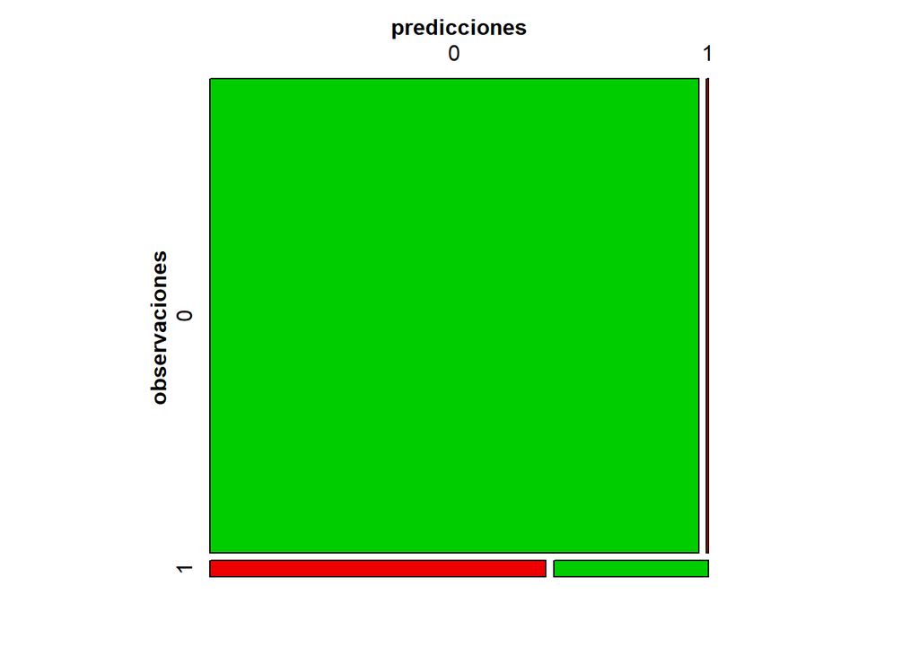

```r
mosaic(matriz_confusion, shade = T, colorize = T, gp = gpar(fill = matrix(c("green3", "red2", "red2", "green3"), 2, 2)))
```

La matriz de confusión muestra un problema de calificación de clase 1

Separación en muestra de entrenamiento y test para obtener métricas de test

```r
library(pROC)
set.seed(20231)
entrenamiento<-sample(1:500,70)

validacion<-c(1:500)[-entrenamiento]

morosos_train<-morosos[entrenamiento,]
morosos_test<-morosos[validacion,]
bin_mora_train<-morosos$bin_mora[entrenamiento]
table(bin_mora_train)
```

```
## bin_mora_train
##  0  1
## 67  3
```

```r
bin_mora_test<-morosos$bin_mora[validacion]
table(bin_mora_test)
```

```
## bin_mora_test
##   0   1
## 417  13
```

```r
morosos_new<-data.frame(morosos_test)
morosos_new$origen<-bin_mora_test

# Se obtienen las probabilidades predichas para cada clase
predicciones <- predict(object = modelo_logistico4, newdata = morosos_new, type = "response")

curva_roc <- roc(response = morosos_new$origen, predictor = predicciones, levels = c(0, 1), direction = "<")
```

```r
curva_roc
```

```
##
## Call:
## roc.default(response = morosos_new$origen, predictor = predicciones,     levels = c(0, 1), direction = "<")
##
## Data: predicciones in 417 controls (morosos_new$origen 0) < 13 cases (morosos_new$origen 1).
## Area under the curve: 0.9662
```

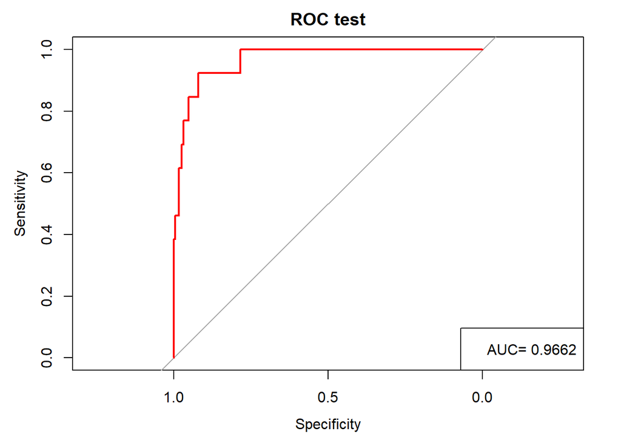

```r
# Gráfico de la curva
#plot(curva_roc)
plot(curva_roc,col="red",lwd=2,main="ROC test")
legend("bottomright",legend=paste("AUC=",round(auc(curva_roc),4)))
```

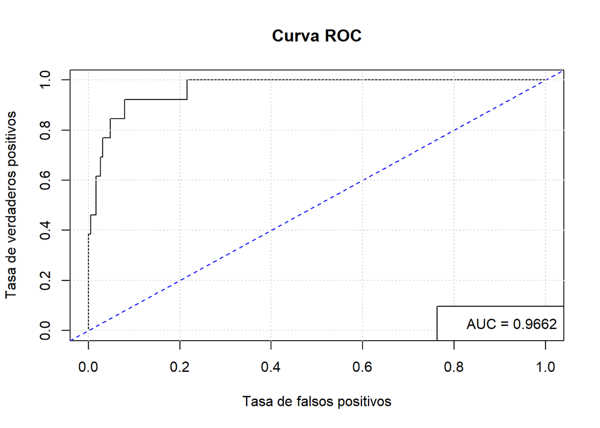

```r
# otra forma
#install.packages("ROCR", repos = "http://cran.us.r-project.org", dependencies = TRUE)
library(ROCR)

real <- morosos_new$origen

predic <-prediction(predicciones,real)
perf <-  performance(predic, "tpr","fpr")

plot(perf,
     main = "Curva ROC",
     xlab="Tasa de falsos positivos",
     ylab="Tasa de verdaderos positivos")
abline(a=0,b=1,col="blue",lty=2)
grid()
auc <- as.numeric(performance(predic,"auc")@y.values)
legend("bottomright",legend=paste(" AUC =",round(auc,4)))
```

funcion curva ROC

```r
curvaROC <- function(muestra,No.muestra,dataset,x,modelo){
 #muestra: numero de muestra de la población
 #No.muestra: No. de datos de la muestra
 #dataset: Conjunto de datos utilizado
 #x: Variable predictora
 #modelo: Modelo utilizado para hacer el ajuste.

  set.seed(20231)


  entrenamiento<-sample(1:muestra,No.muestra)

  validacion<-c(1:muestra)[-entrenamiento]


  # Crear una nueva variable binaria para representar 'x'
  dataset$bin_x <- ifelse(x == "Yes", 1, 0)

  dataset_train<-dataset[entrenamiento,]
  dataset_test<-dataset[validacion,]
  bin_x_train<-dataset$bin_x[entrenamiento]
  table(bin_x_train)

  bin_x_test<-dataset$bin_x[validacion]
  dataset_new<-data.frame(dataset_test)
  dataset_new$origen<-bin_x_test

  real <- dataset_new$origen


  dataset_new<-data.frame(dataset_test)
  dataset_new$origen<-bin_x_test
  # Se obtienen las probabilidades predichas para cada clase
  predicciones <- predict(object = modelo, newdata = dataset_new, type = "response")


  predic <-prediction(predicciones,real)
  perf <-  performance(predic, "tpr","fpr")

  g=plot(perf,
     main = "Curva ROC",
     xlab="Tasa de falsos positivos",
     ylab="Tasa de verdaderos positivos")
  abline(a=0,b=1,col="blue",lty=2)
  grid()
  auc <- as.numeric(performance(predic,"auc")@y.values)
  legend("bottomright",legend=paste(" AUC =",round(auc,4)))
  return(g)
}
```

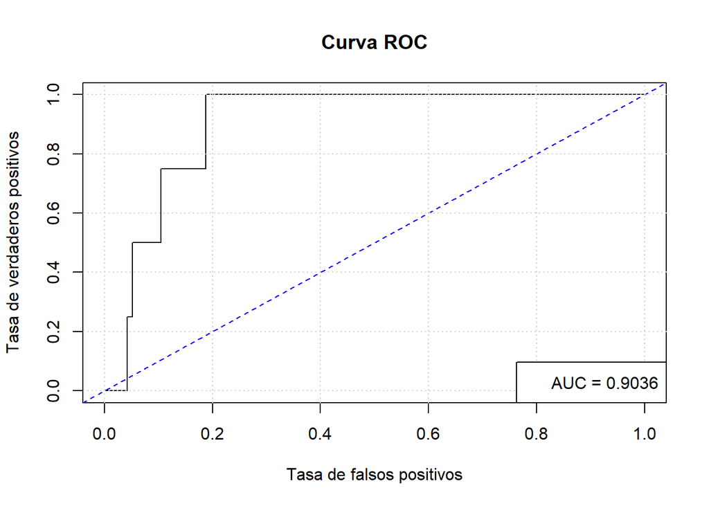

```r
mora=morosos$mora
curvaROC(500,400,morosos,mora,modelo_logistico)
```

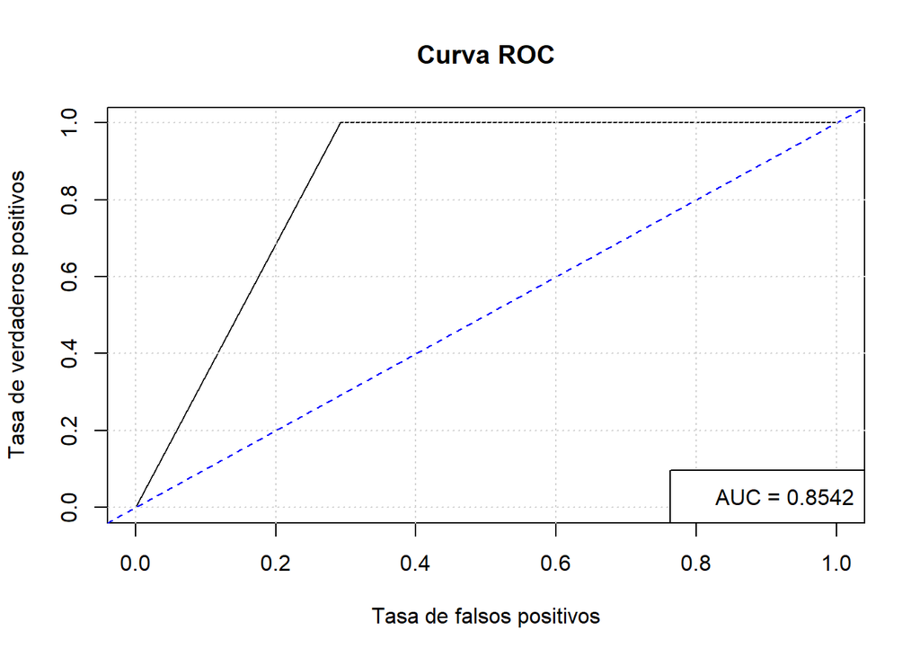

```r
curvaROC(500,400,morosos,mora,modelo_logistico2)
```

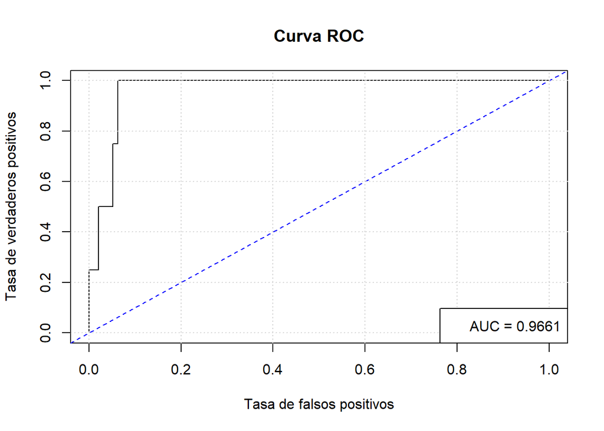

```r
curvaROC(500,400,morosos,mora,modelo_logistico3)
```

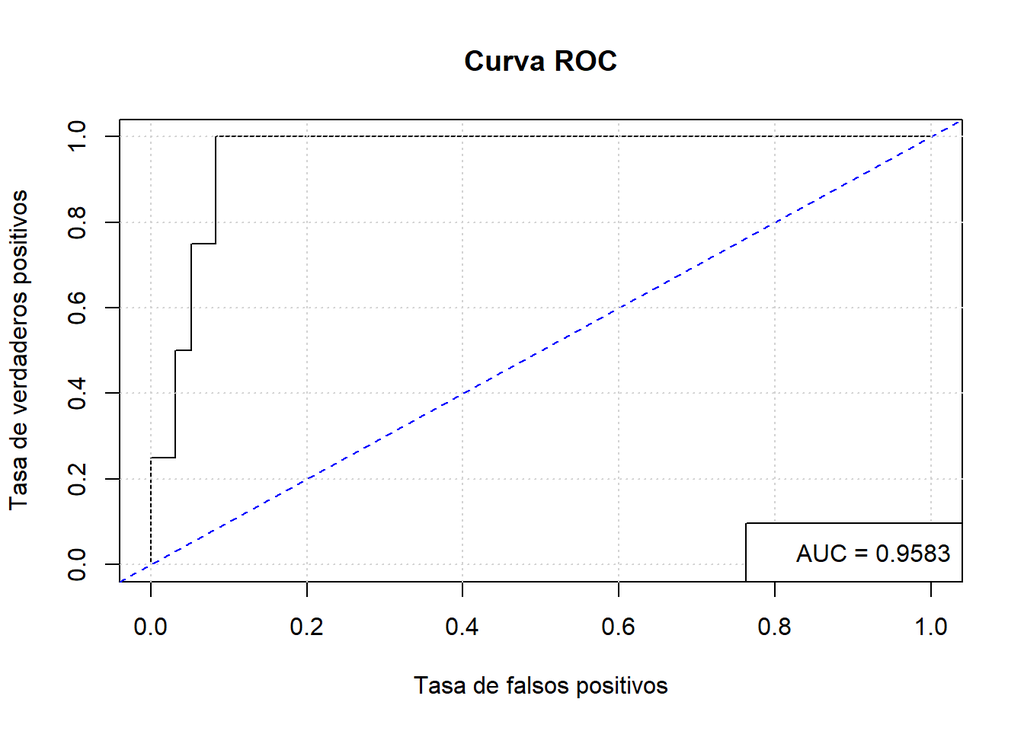

```r
curvaROC(500,400,morosos,mora,modelo_logistico4)
```

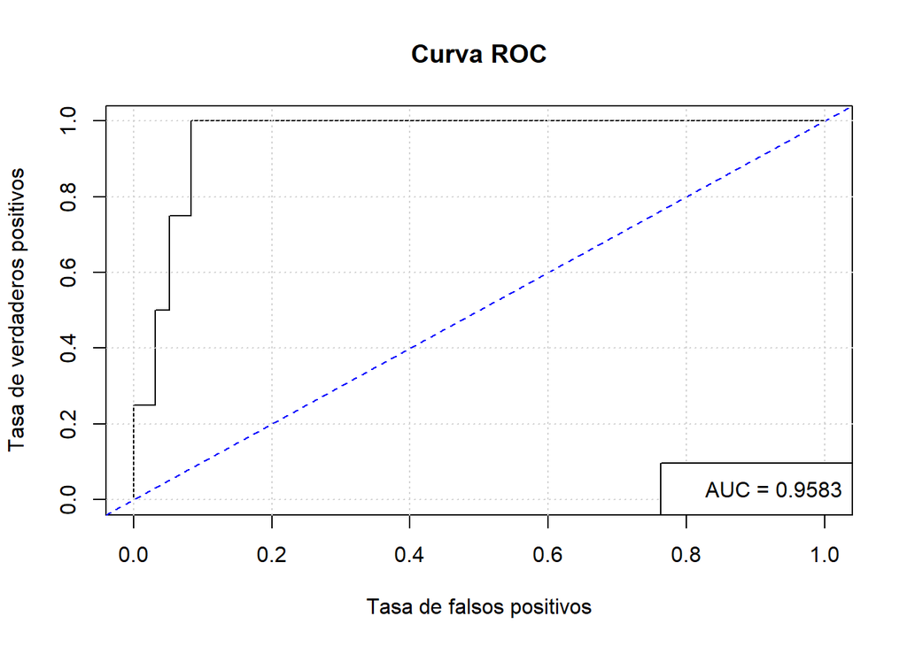

```r
curvaROC(500,400,morosos,mora,modelo_logistico5)
```

Precision : TP / (TP+FP)

Recall : TP / (TP+FN)

F1 Score : (2 * Precision * Recall) / (Precision+Recall)

```r
actual_values<-bin_mora_test
predict_value<-predicciones
table(ACTUAL=actual_values,PREDICTED=predict_value>0.5) # asumimos umbral de 0.5
```

```
##       PREDICTED
## ACTUAL FALSE TRUE
##      0   417    0
##      1     8    5
```

```r
pred<-predict_value>0.5
TP<-length(actual_values[(actual_values==1)&(pred==1)])#15
TN<-length(actual_values[(actual_values==0)&(pred==0)])#12
FP<-length(actual_values[(actual_values==0)&(pred==1)])#1
FN<-length(actual_values[(actual_values==1)&(pred==0)])#2

precision<-TP/(TP+FP)
precision
```

```
## [1] 1
```

La precisión es una medida de la exactitud del modelo en la clasificación de las muestras positivas. Se calcula como el cociente entre los verdaderos positivos (TP) y la suma de los verdaderos positivos y los falsos positivos (FP).

El valor obtenido de la precisión es 1, lo que indica una precisión perfecta. Esto significa que todas las muestras clasificadas como positivas por el modelo son realmente positivas, sin ningún falso positivo.

```r
recall<-TP/(TP+FN)
recall
```

```
## [1] 0.3846154
```

El recall, también conocido como exhaustividad o sensibilidad, es una medida de qué tan bien el modelo identifica las muestras positivas. Se calcula como el cociente entre los verdaderos positivos (TP) y la suma de los verdaderos positivos y los falsos negativos (FN).

El valor del recall es 0.3846154, lo que indica que el modelo identifica correctamente aproximadamente el 38.46% de todas las muestras positivas. Esto significa que hay una proporción de muestras positivas que no son detectadas por el modelo y se clasifican erróneamente como negativas (falsos negativos).

```r
f1_score<-(2*precision*recall)/(precision+recall)
f1_score
```

```
## [1] 0.5555556
```

El F1-score es una medida que combina la precisión y el recall en una sola métrica, proporcionando una evaluación más completa del rendimiento del modelo en la clasificación.

El valor del F1-score es 0.5555556, lo que indica un equilibrio entre la precisión y el recall. Un F1-score de 1 representa un rendimiento óptimo, mientras que un valor cercano a 0 indica un rendimiento pobre.

Conclusión El modelo que se está evaluando tiene una precisión perfecta de 1, lo que significa que todas las muestras clasificadas como positivas son realmente positivas, sin ningún falso positivo. Sin embargo, el recall es de 0.3846154, lo que indica que solo se están identificando correctamente alrededor del 38.46% de todas las muestras positivas. Esto significa que hay un número significativo de falsos negativos, es decir, muestras positivas que no se están detectando.

El F1-score, que combina tanto la precisión como el recall en una sola métrica, es de 0.5555556. Esto indica un equilibrio razonable entre la precisión y el recall, pero aún hay margen de mejora en el rendimiento del modelo.

En general, un modelo con una precisión perfecta y un recall bajo puede indicar que el modelo está clasificando correctamente los casos positivos, pero también está perdiendo una cantidad considerable de casos positivos que no se están detectando. Es posible que el modelo esté siendo demasiado conservador en su clasificación y está evitando falsos positivos, pero a costa de perder verdaderos positivos.

Estimación del error

```r
pred_test_RegLog_0_1<-ifelse(predict_value>0.5,1,0)#idem pred
error_RegLog<- mean(bin_mora_test!= pred_test_RegLog_0_1) * 100
error_RegLog
```

```
## [1] 1.860465
```

El valor del error_RegLog es 1.860465, lo que indica que el modelo de regresión logística tiene una tasa de error de clasificación del 1.860465%. Esto significa que aproximadamente el 1.860465% de las muestras en el conjunto de prueba se clasifican incorrectamente por el modelo.

La tasa de error de clasificación es una medida comúnmente utilizada para evaluar el rendimiento de los modelos de clasificación. Un valor bajo de error indica un mejor rendimiento del modelo, mientras que un valor alto indica un rendimiento deficiente. En este caso, un error del 1.860465% sugiere un rendimiento generalmente bueno del modelo de regresión logística.

función metricas

```r
metricas <- function(modelo, dataset, muestra, NoDeLaMuestra, bin_mora) {
  resultado <- matrix(0, nrow = 6, ncol = 2)

  set.seed(20231)

  entrenamiento <- sample(1:muestra, NoDeLaMuestra)
  validacion <- c(1:muestra)[-entrenamiento]

  dataset_train <- dataset[entrenamiento, ]
  dataset_test <- dataset[validacion, ]
  bin_x_train <- bin_mora[entrenamiento]
  bin_x_test <- bin_mora[validacion]

  dataset_new <- data.frame(dataset_test)
  dataset_new$origen <- bin_x_test

  predicciones <- predict(object = modelo, newdata = dataset_new, type = "response")
  predict_value <- predicciones

  pred <- predict_value > 0.5
  TP <- sum(bin_x_test[pred] == 1)
  TN <- sum(bin_x_test[!pred] == 0)
  FP <- sum(bin_x_test[pred] == 0)
  FN <- sum(bin_x_test[!pred] == 1)

  resultado[1, 1] <- "Metricas"
  resultado[1, 2] <- "Resultado"

  resultado[2, 1] <- "precision"
  resultado[2, 2] <- precision <- TP / (TP + FP)

  resultado[3, 1] <- "recalln"
  resultado[3, 2] <- recall <- TP / (TP + FN)

  resultado[4, 1] <- "f1_score"
  resultado[4, 2] <- f1_score <- (2 * precision * recall) / (precision + recall)

  pred_test_RegLog_0_1 <- ifelse(predict_value > 0.5, 1, 0)
  error_RegLog <- mean(bin_x_test != pred_test_RegLog_0_1) * 100

  resultado[5, 1] <- "error"
  resultado[5, 2] <- error_RegLog

  # Calcular matriz de confusión
  matriz_confusion <- table(predicciones, bin_x_test)

  # Calcular métricas
  #precision <- matriz_confusion[2, 2] / sum(matriz_confusion[, 2])
  #recall <- matriz_confusion[2, 2] / sum(matriz_confusion[2, ])
  #f1_score <- 2 * precision * recall / (precision + recall)
  exactitud <- sum(diag(matriz_confusion)) / sum(matriz_confusion)

  resultado[6, 1] <- "exactitud"
  resultado[6, 2] <- exactitud

  return(resultado)
}
```

```r
metricas(modelo_logistico4, morosos, 500, 70, morosos$bin_mora)
```

```
##      [,1]        [,2]
## [1,] "Metricas"  "Resultado"
## [2,] "precision" "1"
## [3,] "recalln"   "0.384615384615385"
## [4,] "f1_score"  "0.555555555555556"
## [5,] "error"     "1.86046511627907"
## [6,] "exactitud" "0.00232558139534884"
```

Para comparar el modelo se utiliza un clasificador basado en Random forest

```r
#install.packages("randomForest")
library(randomForest)
#morosos_train$bin_mora <- factor(morosos_train$bin_mora)
morosos_train$estudiante <- factor(morosos_train$estudiante)
modelo_rf <- randomForest(bin_mora ~ ingreso+estudiante+balance, data = morosos_train, class.factors = TRUE)
#prediccionesrf <- predict(modelo_rf, newdata = morosos_test)
```

```r
calcularMetricasRandomForest <- function(modelo, datos, variable_objetivo) {
  # Realizar predicciones utilizando el modelo
  predicciones <- predict(modelo, datos)

  # Calcular matriz de confusión
  matriz_confusion <- table(predicciones, datos[[variable_objetivo]])

  # Calcular métricas
  precision <- matriz_confusion[2, 2] / sum(matriz_confusion[, 2])
  recall <- matriz_confusion[2, 2] / sum(matriz_confusion[2, ])
  f1_score <- 2 * precision * recall / (precision + recall)
  exactitud <- sum(diag(matriz_confusion)) / sum(matriz_confusion)


  # Crear matriz de resultados
  resultados <- matrix(0, nrow = 6, ncol = 2)
  resultados[1, ] <- c("Métrica", "Valor")
  resultados[2, ] <- c("Precision", precision)
  resultados[3, ] <- c("Recall", recall)
  resultados[4, ] <- c("F1-Score", f1_score)
  resultados[5, ] <- c("Exactitud", exactitud)

  pred_test_RegLog_0_1 <- ifelse(as.numeric(predicciones) > 0.5, 1, 0)
  error_RegLog <- mean(datos[[variable_objetivo]] != pred_test_RegLog_0_1) * 100

  resultados[6, 1] <- "error"
  resultados[6, 2] <- error_RegLog

  return(resultados)
}
```

```r
morosos_test$estudiante <- factor(morosos_test$estudiante)
# Calcular métricas de evaluación
resultados_metricas <- calcularMetricasRandomForest(modelo_rf, morosos_test, "bin_mora")
```

```r
# Imprimir resultados
print(resultados_metricas)
```

```
##      [,1]        [,2]
## [1,] "Métrica"   "Valor"
## [2,] "Precision" "0"
## [3,] "Recall"    "0"
## [4,] "F1-Score"  "NaN"
## [5,] "Exactitud" "0.323255813953488"
## [6,] "error"     "3.02325581395349"
```

Se observa que el primer modelo es mejor.